# Exploratory analysis of Atlantic hurricanes

Rohit Tahade

June 2021

```r
#calling required libraries
library(tidyverse)
```

```r
library(maps)
#Loading hurricane data
# Load the data file using a relative path
load("./processed_data/Hurdat2_tidy.RData")
```

## Question 1 : What’s in this dataset?

#### a. Load the dataframe. Pick one famous hurricane that you know the name and make a dataframe similar to hurrs but containing only the data for your chosen hurricane. (Note that the people who name hurricanes have reused names sometimes.)

```r
hurrs %>% filter(name=="MARIA") %>% filter(str_detect(id,"AL14")) -> maria
```

#### b. Write a function called Hurdat2_summary that takes the hurrs dataframe as an input and returns a named list containing

• the total number of storms • the range of years covered • a vector containing the number of track points for each storm

```r
Hurdat2_summary <- function(df){
  #count the total number of storms
  total_storms<- summarise(df,count=n())

  #range of years covered
  range<-summarise(df,from=min(year),To=max(year))

  #a vector containing the number of track points for each storm
  track_points<- group_by(df,name) %>% summarise(total_track_pt=n())


  track_points <- setNames(as.numeric(track_points$total_track_pt),as.character(track_points$name))
  list("Total no. of Storms"=total_storms,"Range of years covered"=range,"Track Points of each storm"=track_points)
}
```

*Test your function by running it for three cases: • the full hurrs dataframe • a version that has been filtered to contain only storms from a single year • the one-hurricane dataframe you made in (a)

- Test 1

  ```r
  Hurdat2_summary(hurrs)
  ```

  ```
  ## $`Total no. of Storms`
  ## # A tibble: 1 × 1
  ##   count
  ##   <int>
  ## 1 52717
  ##
  ## $`Range of years covered`
  ## # A tibble: 1 × 2
  ##    from    To
  ##   <dbl> <dbl>
  ## 1  1851  2020
  ##
  ## $`Track Points of each storm`
  ##       ABBY       ABLE      AGNES    ALBERTO       ALEX       ALFA      ALICE
  ##         99        153         35        233        125         11        117
  ##     ALICIA      ALLEN    ALLISON       ALMA      ALPHA     AMELIA        AMY
  ##         25         46        121        132         55          6         31
  ##        ANA     ANDREA     ANDREW      ANITA       ANNA     ARLENE     ARTHUR
  ##        172         52         68         20        146        322        172
  ##     AUDREY       BABE      BAKER    BARBARA      BARRY      BECKY      BELLE
  ##         20         24        115         40        165        113         18
  ##     BERTHA      BERYL       BESS       BETA       BETH      BETSY      BETTY
  ##        275        181         13         52         29        182         42
  ##     BEULAH       BILL    BLANCHE        BOB     BONNIE     BRENDA       BRET
  ##        165         99         30        105        273        124        139
  ##    CAMILLE    CANDICE      CANDY      CARLA     CARMEN      CAROL   CAROLINE
  ##         37         25         15         98         49        152         33
  ##     CARRIE      CELIA      CESAR    CHANTAL    CHARLEY    CHARLIE      CHLOE
  ##        124         99         61        171        163        153         97
  ##      CHRIS  CHRISTINE      CINDY      CLARA  CLAUDETTE       CLEO      COLIN
  ##        198         42        215         27        214        153         40
  ##     CONNIE       CORA  CRISTOBAL      DAISY   DANIELLE      DANNY      DAVID
  ##         49         19        115         71        214        190         55
  ##       DAWN       DEAN     DEBBIE      DEBBY      DEBRA      DELIA      DELTA
  ##         39        148        134        170         59         23         98
  ##     DENNIS      DIANA      DIANE        DOG      DOLLY        DON      DONNA
  ##        255         58         67        138        201         21         72
  ##       DORA      DORIA     DORIAN      DORIS    DOROTHY     DOTTIE       EARL
  ##         87         91        121         29         77         15        211
  ##       EASY      EDITH       EDNA    EDOUARD      EIGHT     ELAINE      ELENA
  ```

  [output cut: 46 more lines]

  ```
  ##         50         84         15         80        118         19          9
  ##       NOEL     ODETTE       OLGA       OMAR        ONE       OPAL    OPHELIA
  ##        113         23         82         59         15         39        175
  ##      OSCAR       OTTO      PABLO     PALOMA      PATTY      PAULA   PAULETTE
  ##         49        124         38         36         11         21         88
  ##      PETER   PHILIPPE     RAFAEL    REBEKAH       RENE    RICHARD       RINA
  ##         15        100         56         23         32         29         52
  ##       RITA    ROXANNE      SALLY      SANDY       SEAN  SEBASTIEN      SHARY
  ##         36         56         28         45         28         53          9
  ##    SIXTEEN       STAN      TAMMY      TANYA      TEDDY        TEN      THETA
  ##          8         17          9         29         49         48         33
  ##      THREE      TOMAS       TONY TWENTY-TWO        TWO    UNNAMED      VICKY
  ##          5         54         20         27         30      26792         24
  ##      VINCE    WILFRED      WILMA       ZETA
  ##         15         17         48         61
  ```

- Test 2

  ```r
  Hurdat2_summary(filter(hurrs,year==2005))
  ```

  ```
  ## $`Total no. of Storms`
  ## # A tibble: 1 × 1
  ##   count
  ##   <int>
  ## 1   907
  ##
  ## $`Range of years covered`
  ## # A tibble: 1 × 2
  ##    from    To
  ##   <dbl> <dbl>
  ## 1  2005  2005
  ##
  ## $`Track Points of each storm`
  ##      ALPHA     ARLENE       BETA       BRET      CINDY      DELTA     DENNIS
  ##         11         26         18          7         34         42         59
  ##      EMILY    EPSILON   FRANKLIN      GAMMA       GERT     HARVEY      IRENE
  ##         45         43         38         33          9         46         56
  ##       JOSE    KATRINA        LEE      MARIA       NATE   NINETEEN    OPHELIA
  ##          6         34         26         51         29          9         69
  ##   PHILIPPE       RITA       STAN      TAMMY        TEN TWENTY-TWO    UNNAMED
  ##         28         36         17          9         21         27          7
  ##      VINCE      WILMA       ZETA
  ##         15         48          8
  ```

- Test 3

  ```r
  Hurdat2_summary(maria)
  ```

  ```
  ## $`Total no. of Storms`
  ## # A tibble: 1 × 1
  ##   count
  ##   <int>
  ## 1    93
  ##
  ## $`Range of years covered`
  ## # A tibble: 1 × 2
  ##    from    To
  ##   <dbl> <dbl>
  ## 1  2005  2011
  ##
  ## $`Track Points of each storm`
  ## MARIA
  ##    93
  ```

#### c. Make a histogram of the number of track points, using the output of your function for the hurrs case.

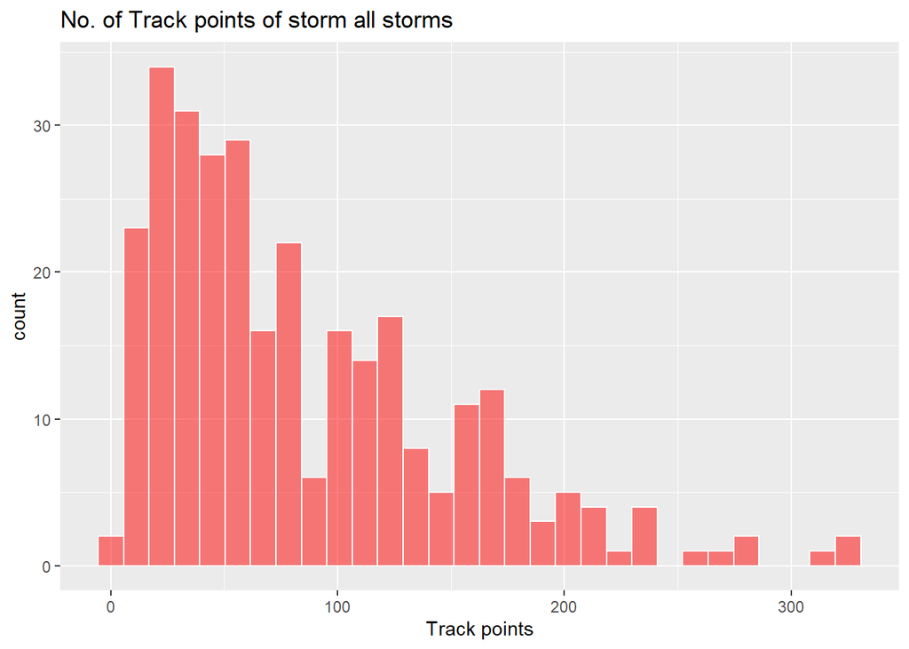

```r
 #converted list to a data frame
histplot<-as.data.frame(Hurdat2_summary(hurrs))
# Taking rownames into name column
histplot<-rownames_to_column(histplot,"name")
# filtering out unnamed storms and plotting histogram
histplot %>% filter(name!="UNNAMED") %>%
             ggplot() +
             geom_histogram(aes(x=Track.Points.of.each.storm),alpha=0.5,color="white", fill="red") +
             labs(title = "No. of Track points of storm all storms", x= "Track points")
```

#### d. What year did they begin naming hurricanes and other storms?

```r
#Arranging as per year
hurrs %>% arrange(year) %>%
#filtering out unnamed storms
filter(name!="UNNAMED") %>%
#selecting first named entry and converting to numeric vector
head(1) %>% select(year) %>% as.numeric() -> year_name
#printing result
print(paste("They began naming hurricanes and other storms in year ",year_name))
```

```
## [1] "They began naming hurricanes and other storms in year  1950"
```

# Question 2: Mapping

#### a. plot all the storms in the database atop a simple world map.

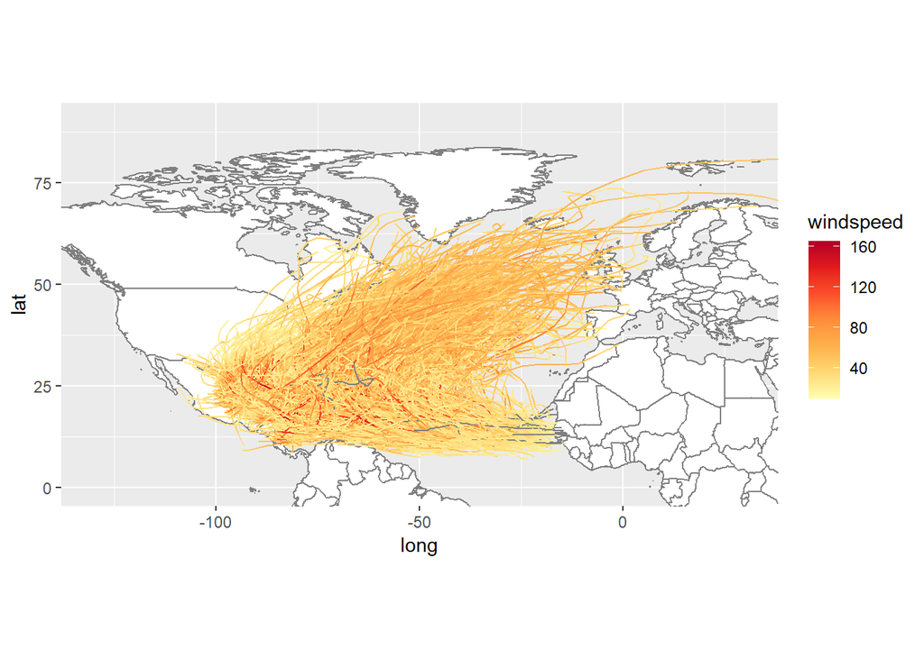

```r
#install.packages("maps") #Installing "maps" Package

#defining a function to plot world map using 'ggplot2' and 'map' libraries
hurricaneBasemap = function() {

  #converting 'world' map from 'maps' package into dataframe
  world = map_data("world")

  basemap = ggplot() +
    #from 'hurrs' dataset,
    #min(longitude)=-110,max(longitude)= 63
    #min(latitude)=7.2, max(latitude)= 81
    # So, fixing coordinates considering some offset value
    coord_fixed(xlim=c(-130,30),ylim=c(0,90)) +

    #plotting world map using data from 'world' dataframe
    geom_polygon(data=world, aes(x=long,y=lat,group=group), color="gray50", fill="white")
  return(basemap)
}
hurricaneBasemap() +

  #connecting observations from each hurricane id
  geom_path(data=hurrs, aes(x=longitude,y=latitude,group=id,color=windspeed)) +

  #Giving sequential coloring to observations as per wind speed. sequence followed: Yellow to Red
  scale_color_distiller(type="seq",direction=1,palette="YlOrRd")
```

#### b. write a function that takes a year as input and makes a similar plot for only the hurricanes during that year. The function doesn’t need to return a value, but it does need to generate a plot. Test your function by making the plot for a year of your choice.

function to plot hurricanes during specific year

```r
hurricane_in_year<- function(in_year){

  #filtering hurrs data as per year provided in argument
  hurrs_year <- hurrs %>% filter(year==in_year)

  #Plotting the hurricane data using function and plots used in question 2a
  hurricaneBasemap() +
    geom_path(data=hurrs_year, aes(x=longitude,y=latitude,group=id,color=windspeed)) +
    scale_color_distiller(type="seq",direction=1,palette="YlOrRd") +
    labs(title = paste("Hurricanes in year",in_year),x="Longitude",y="Latitude")
}
```

plotting hurricanes in year 1990

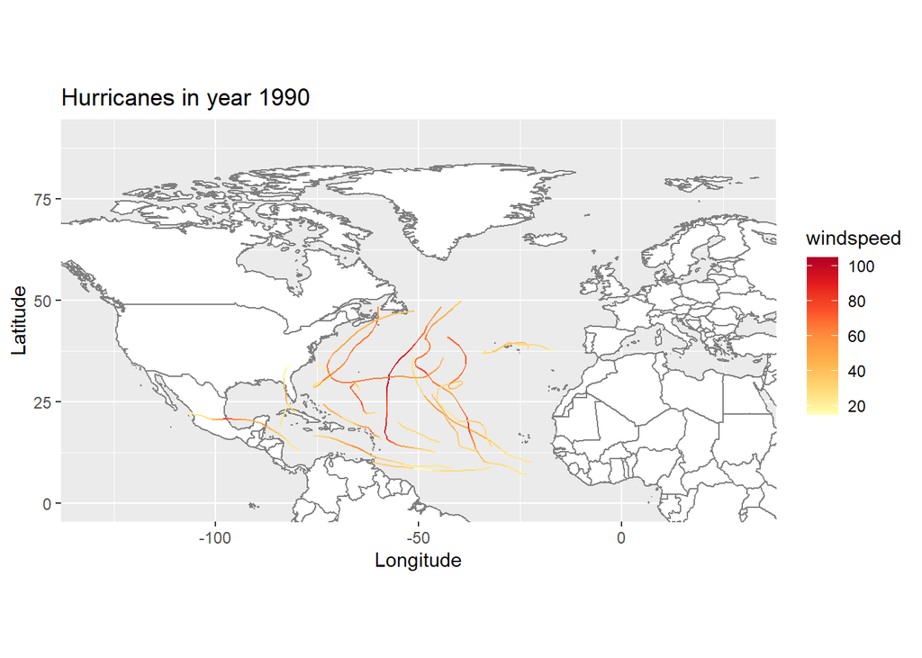

```r
hurricane_in_year(1990)
```

# Question 3: The local perspective

## a. Using the formula given in project introduction, write a function that calculates distance between (lon1,lat1) and (lon2,lat2). Test it.

loading word.cities database containing coordinates of cities from ’maps’package

```r
cities = world.cities
```

defining a function to calculate distance from latitude and longitude coordinates

```r
distance_between <- function(lon1, lat1, lon2, lat2) {
  dx = (lon2 - lon1) * cos(pi * (lat1 + lat2) / 360)
  dy = lat2 - lat1

  D = 111.325 * sqrt(dx ^ 2 + dy ^ 2)
  return(D)
}
```

Distance between Leeds and Cardiff

```r
distance_between(-1.55, 53.81, -3.18, 51.48)
```

```
## [1] 281.7871
```

*Distance between Leeds and Cardiff is* 281.7871166 km

#### b. Adapt your function so that instead of (lon2,lat2) it takes the name of a city as input, finds its latitude– longitude coordinates, and returns the distance to (lat1,lon1). Test it. Give this function a new name and have it call the function from part (a).

```r
#defining function to calculate distance of city from coordinates
city_distance <- function(lon1, lat1, city_name) {
  lon2 <-cities %>% filter(name == city_name) %>% select(long) %>% as.numeric()
  lat2 <-cities %>% filter(name == city_name) %>% select(lat)  %>% as.numeric()
  distance_between(lon1, lat1, lon2, lat2)
}
```

Calling the function

```r
#Distance between Leeds and Lisburn
city_distance(-1.55, 53.81, "Lisburn")
```

```
## [1] 304.3833
```

Distance between Leeds and Lisburn 304.3833107 km

#### c. A common mistake in working with latitudes and longitudes is to swap them around. It isn’t always possible to catch user errors of this sort, but one test is that longitude can take values from -180 to 180 while latitude is always -90 to 90. Modify your function to check whether it’s likely that the user has swapped lat1 and lon1 and if so, provide a useful warning message.

defining function to check if entered coordinates are in correct range

```r
coord_check <- function(lon1, lat1, city_name) {
  if (-180 > lon1 | lon1 > 180){
    warning("Enter correct Longitude!")
  }
  else if(-90 > lat1 | lat1 > 90) {
    warning("Enter correct Latitude!")
  }
  else {
    lon2 <- cities %>% filter(name == city_name) %>% select(long) %>% as.numeric()
    lat2 <- cities %>% filter(name == city_name) %>% select(lat)  %>% as.numeric()
    distance_between(lon1, lat1, lon2, lat2)
  }
}
```

calling the function

```r
#checking with wrong latitude
#It should show warning:"Enter correct Latitude!"
coord_check( -3.18, 92, "Lisburn")
```

[output not shown]

#### d. Choose an eastern North American or Caribbean city, and use your function to determine which storms passed within 100 km of it. Plot those storms on a map like those in Q1, with a dot on top showing where the city is.

function to find storms passed within 100km radius of a city

```r
near_city_100km<- function(city_name){
  city_coord<- filter(cities, name == city_name) #filtering city name
  #finding city coordinates
  lon1<- city_coord$long
  lat1<- city_coord$lat
  #adding a distance column containing distance of city from storm
  distance_100<- hurrs %>% mutate(distance = distance_between(lon1,lat1,longitude,latitude)) %>%
    filter(distance<100) #filtering storms within 100km radius
  return( distance_100) # returning same filtered table
}
```

calling the function with city name New York

```r
near_city_100km("New York")
```

```
## # A tibble: 38 × 12
##    id     name   year month   day status latit…¹ longi…² winds…³ isLan…⁴ isHur…⁵
##    <chr>  <chr> <dbl> <dbl> <dbl> <fct>    <dbl>   <dbl>   <dbl> <lgl>   <lgl>
##  1 AL071… UNNA…  1866    10 30.5  EX        41.3   -74        50 FALSE   FALSE
##  2 AL051… UNNA…  1872    10 26.8  TS        40.6   -73.8      40 FALSE   FALSE
##  3 AL061… UNNA…  1874     9 30    TS        40.9   -73.6      60 FALSE   FALSE
##  4 AL041… UNNA…  1882     9 24.2  TS        40.7   -72.8      40 TRUE    FALSE
##  5 AL051… UNNA…  1888     9 12    EX        40.6   -73.3      35 FALSE   FALSE
##  6 AL041… UNNA…  1893     8 24.5  HU        40.7   -73.9      75 TRUE    TRUE
##  7 AL051… UNNA…  1894    10 10.6  HU        40.7   -72.9      75 TRUE    TRUE
##  8 AL061… UNNA…  1900    10 14.5  EX        40.3   -73.7      35 FALSE   FALSE
##  9 AL041… UNNA…  1903     9 16.8  TS        40.3   -75        55 FALSE   FALSE
## 10 AL011… UNNA…  1915     8  4.75 EX        40.9   -74.3      50 FALSE   FALSE
## # … with 28 more rows, 1 more variable: distance <dbl>, and abbreviated
## #   variable names ¹latitude, ²longitude, ³windspeed, ⁴isLandfall, ⁵isHurricane
```

Plotting on map hurricanes within 100km radius of New York

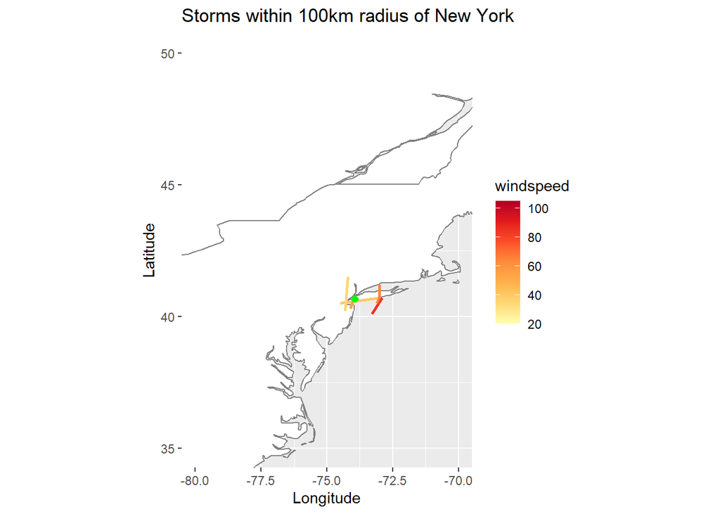

```r
#function to return basemap to plot hurricanes within 100 km of city
hurricaneBasemap1 = function() {
  library(maps) #calling 'maps' library to draw geographical maps

  #converting 'world' map from 'maps' package into dataframe
  world = map_data("world")

  basemap = ggplot() +
    coord_fixed(xlim=c(-80,-70),ylim=c(35,50)) +
    geom_polygon(data=world, aes(x=long,y=lat,group=group), color="gray50", fill="white")
  return(basemap)
}

# Plotting on map hurricanes within 100km radius of New York
hurricaneBasemap1() +

  #connecting observations from each hurricane id
  geom_path(data= near_city_100km("New York"), aes(x=longitude,y=latitude,group=id,color=windspeed),size=1) +

  #Giving sequential coloring to observations as per wind speed. sequence followed: Yellow to Red
  scale_color_distiller(type="seq",direction=1,palette="YlOrRd") + labs(title = "Storms within 100km radius of New York",x="Longitude",y="Latitude") +
  # Green dot showing location of city
  geom_point(data= filter(cities,name=="New York"),aes(x=long,y=lat),color="green",size=2)
```

# Question 4: Climate change

#### a. Globally, the number of hurricane-strength storms has been clearly increasing because of climate change. Is this true in the Atlantic specifically? Plot the number of storms in each year.

Plotting all Hurricane-strength storms count over the years

```r
#counting total storms, hurricanes and storms which are not hurricanes from dataset.
all_storms<-hurrs %>% group_by(year) %>% summarise("all_storms"=n())
hurrs_true<-hurrs %>% group_by(year) %>% filter(isHurricane==TRUE) %>% summarise(hurricane=n())
hurrs_false<-hurrs %>% group_by(year) %>% filter(isHurricane==FALSE) %>% summarise(not_hurricane=n())

#Joing all counts in single dataset 'hurrs all'
hurrs_all <-left_join(hurrs_true,hurrs_false)
hurrs_all <- hurrs_all %>% left_join(all_storms)
```

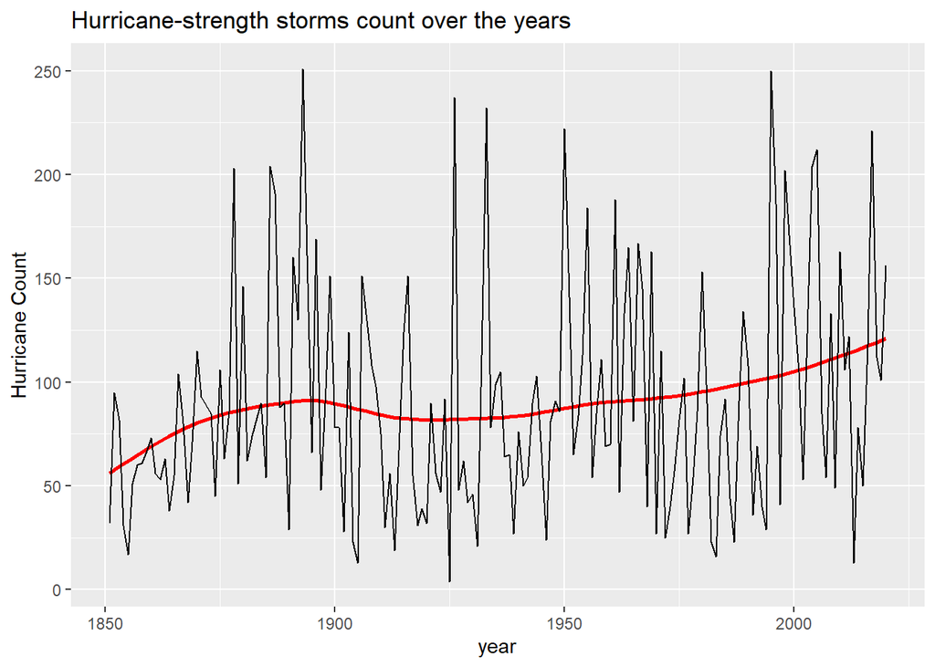

```r
#using gather function to combine all storm count columns to single column
df<-hurrs_all %>% gather(key = "storm_type", value = "storm_count",-year)

#Plotting all Hurricane-strength storms count over the years
ggplot() +
  geom_smooth(data=hurrs_true,aes(x=year,y=hurricane), se=F,color="red",method = 'loess') +
  geom_line(data=hurrs_true,aes(x=year,y=hurricane),color="black") +
  labs(title = "Hurricane-strength storms count over the years", y="Hurricane Count")
```

*The plot shows that, the number of hurricane strength storms is increasing*

plotting count of Hurricane, not Hurricane and All storms counts

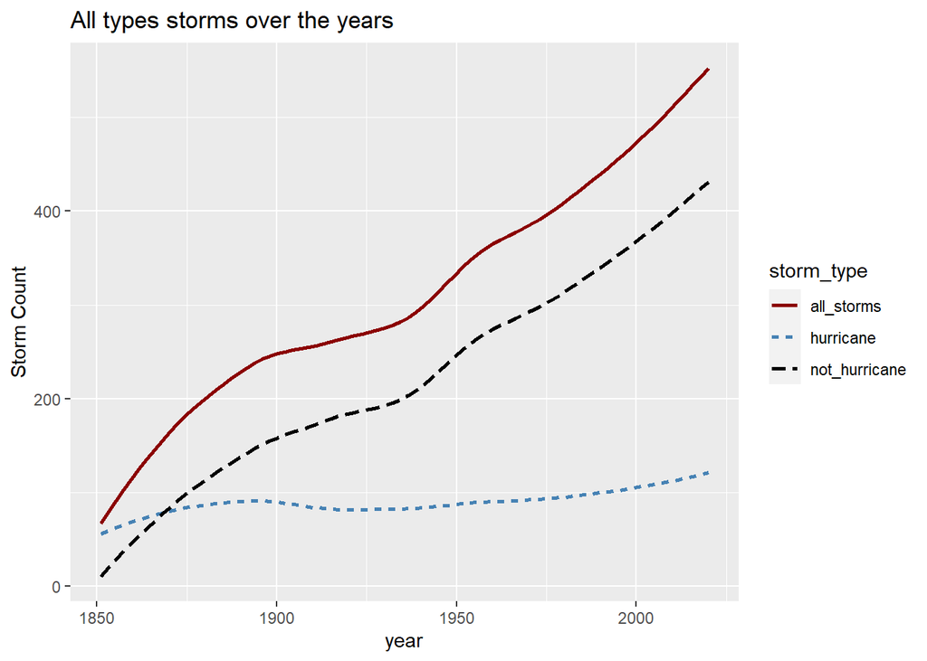

```r
ggplot(df, aes(x = year, y = storm_count)) +
  geom_smooth(aes(color = storm_type, linetype = storm_type,),method = 'loess',se=FALSE) +
  scale_color_manual(values = c("darkred", "steelblue","black")) +
  labs(title = "All types storms over the years", y="Storm Count")
```

*From the plot it is observed that, total number of storms is continuously increasing over the years along with non-hurricane storms. Relatively, There is no significant increase in Hurricane-strength storms*

#### b. The total number isn’t the only aspect of hurricane statistics that might change with climate change. What about the geographical area affected? Make a plot that lets you visually evaluate whether the latitude range where storms cross the coastline (make landfall) is expanding in recent decades. Does your plot suggest any concerns about data quality and data coverage in this database?

Defining a function to plot hurricane landfall from 1851 till specific year

```r
#creating basemap to plot on world map
hurricaneBasemap1 = function() {
  library(maps)
  world = map_data("world")
  basemap = ggplot() + coord_fixed(xlim=c(-120,-20),ylim=c(0,60)) +
    geom_polygon(data=world, aes(x=long,y=lat,group=group), color="gray50", fill="white")
  return(basemap)
}
# Defining a function to plot hurricane landfall from 1851 till specific year
landfall_till<- function(till_year){
  hurrs %>% filter(isLandfall==TRUE,year<=till_year) -> df2
  plot<-hurricaneBasemap1() +
    geom_point(data = df2, aes( x = longitude , y = latitude , group = id , color = year )) +
    scale_color_distiller( type = "seq" , direction = 1 , palette = "YlOrRd" ) +
    labs( title = paste("Hurricane landfall from 1851 to ",till_year))
  return(plot)
}
```

calling the function for making four different plots of hurrican landfalls from 1851 till year 1920,1950,1990,2020 on world map

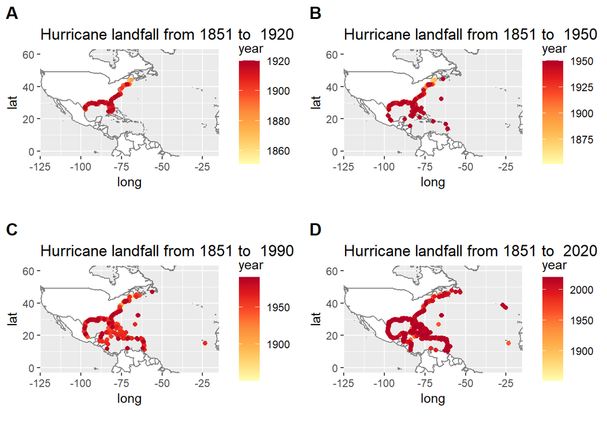

```r
library(ggpubr) # calling necessary library to combine plots
ggarrange(landfall_till(1920),landfall_till(1950), landfall_till(1990), landfall_till(2020),
          labels = c("A", "B", "C","D"),
          ncol = 2, nrow = 2)
```

**It is seen in the graph that over the years,storms making landfall are expanding across eastern coastal regions of USA towards Mexico. Number of landfalls in Caribbean counties is also significantly increased over the years.**

**Data Quality: It looks quiet strange that hardly any hurricane hit any Caribbean country or Mexico from year 1851 to 1920. This raises a question whether data of hurricane landfalls before 1920 is included in this data set or not.**

#### c. Is peak wind speed increasing over time? Answer this using whatever kind of plot or table you think is most helpful.

Plotting Maximum wind speed over the years

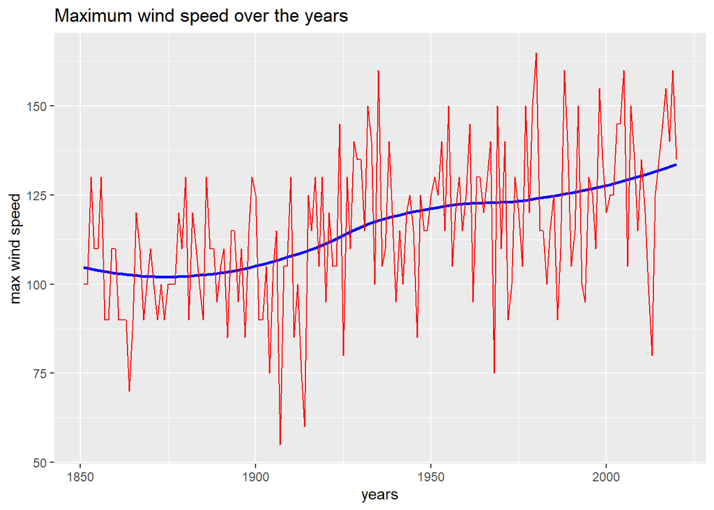

```r
hurrs %>% group_by(year) %>%
  summarise(max.wind=max(windspeed,na.rm = TRUE)) %>%
  ggplot() +
geom_smooth(aes(x=year,y=max.wind,color=year),color='blue',se=F) + geom_line(aes(x=year,y=max.wind),color='red')+
  labs(title = "Maximum wind speed over the years", x="years", y="max wind speed")
```

*The plot shows that maximum wind speed of Hurricanes each year is increasing over the years*

#### d. What about the seasonal timing of hurricanes? First, make a histogram of storms by month over the entire dataset. This should show that there is a distinct hurricane season—they tend to happen at a certain time of year. Use a bin width of 1 month.

Seasonal Timings of Hurricanes

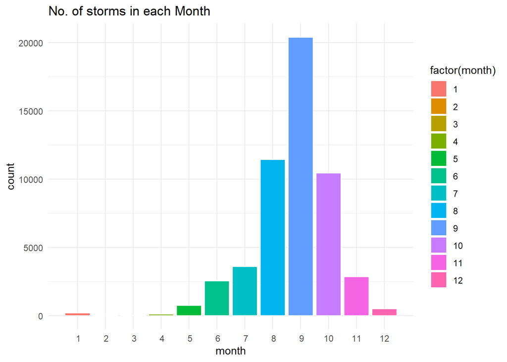

```r
hurrs %>%
  group_by(month) %>%
  summarise(count = n()) %>% # Calculate count for each month
  ggplot(aes(x = month, y = count, fill = factor(month))) +
  geom_bar(stat = "identity", color = "white") +
  scale_x_discrete(limits = 1:12) +
  theme_minimal() +
  labs(title = "No. of storms in each Month")
```

*This plot shows that 8th, 9th,10th month of the year is seasonal timing of Hurricanes*

#### e. add a “decade” column to the hurrs dataframe.

adding “decade” column to the hurrs dataframe

```r
hurrs<- mutate(hurrs,decade=year-year%%10)
```

#### f. make a plot that shows whether “hurricane season” is expanding into earlier and later months of the year over time.

Is “hurricane season” is expanding into earlier and later months of the year over time?

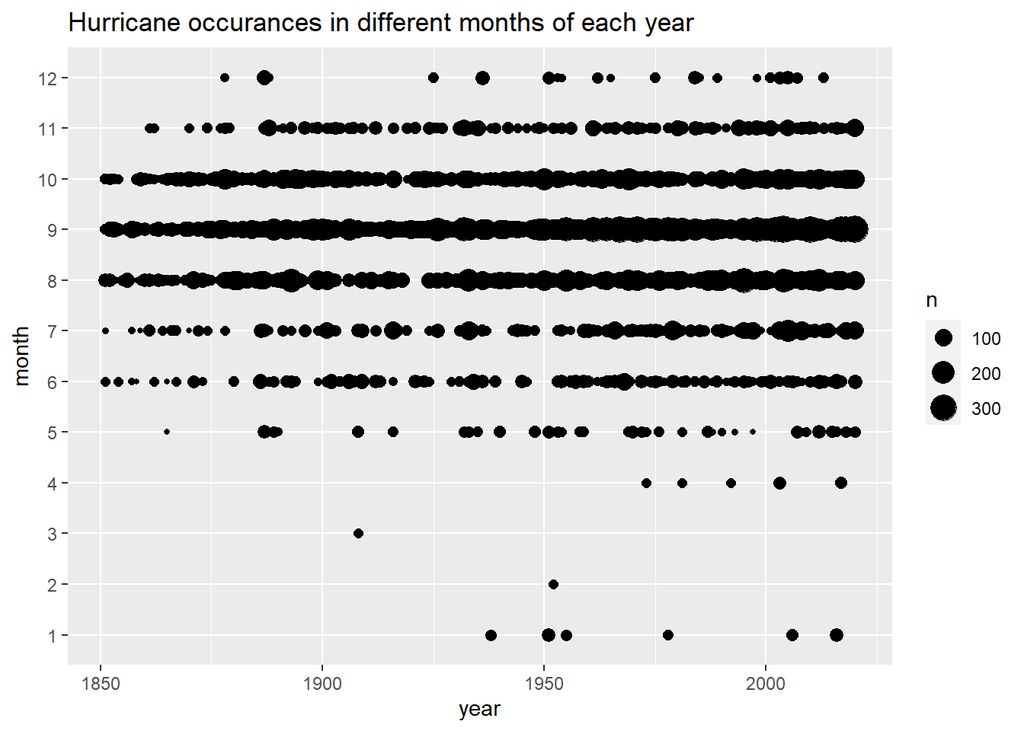

```r
hurrs %>% group_by(month) %>% ggplot() + geom_count(aes(x=year,y=month)) + labs(title = "Hurricane occurances in different months of each year")+ scale_y_discrete(limits=1:12)
```